# Modeling (Overview)

[return to overview page]

Now that we have extracted various features (sentiment, parts of speech, indvidual word counts) and these features have been cleaned, we are ready to use them to build statistical models that can make binary predictions about whether individual statements are truths or lies. Because these models will differ from each other (e.g. logistic regression v. neural nets), it is important to identify common criteria by which the performance of these different models can be assessed and thus compared. In this section my aim is to provide an overview of how we will assess model performance.

At a very high level, our modeling process will have two basic components. First, we build the model (“model training”). Second, we assess its performance (“model testing”).

(The model should be trained on separate data from the data it is tested on. In the final part of this section, “Data Splitting, for Model Training and Testing”, we will review various strategies for splitting a dataset into portions for testing and training. For now, assume we have done this correctly and are at the model “testing” phase.)

The setup for model testing will always be the same. We will have a set of statements (from which various textual features have been extracted), our “testing set”. For each statement in this testing set, the model will be fed the value of the features for that statement (e.g. statement length, sentiment score), and it will spit out a prediction for each of those statements. We can then compare these predictions to reality. Most obviously, we can look at overall accuracy (# correct predictions / # of predictions). But other important metrics exist as well: sensitivity, specificity, precision, and negative predictive value. I review these below, using example data.

(Note, this is all occuring in the domain of “binary classification”, and “classification” more generally. Models that perform classification aim to predict membership of items in discrete categories or “classes”. Here, we are predicting whether a statement belongs in the class “lies” or the class “truths”. Other binary classification tasks might including predicting a whether a person will or will not default on a loan based on their previous financial history. Not all classification tasks are binary; for example, one might try to build a model that takes in images of animals and uses features extracted from those images, to predict what species of animal is in those pictures, e.g. dog, cat, elephant. And finally, an entirely different domain of prediction involves making predictions about continuous quantities, e.g. predicting someone’s expected salary based on features like their education and previous employment history. Different metrics, like root mean squared error, are used to assess the performance of models that make predictions about continuous quantities. These are not covered here.)

(Interestingly, the metrics we will review for assessing model performance in our binary classification task can (and will) also be used to quantify human lie detection performance.)

# Packages

As usual I wil start with the house-keeping matter of loading some packages that will be used in this section.

```r
# before knitting: message = FALSE, warning = FALSE
library(tidyverse) # cleaning and visualization
library(ggthemes) # visualization
```

# Confusion Matrix

We will focus on five key performance statistics (overall accuracy, sensitivity, specificity, precision, and negative predictive value). All of these statistics can be derived from a table that is central to evaluating performance in binary classification. This table is called a “confusion matrix” and is a 2x2 table that cross-tabulates predictions and actual outcomes (I use the terms “actual outcomes” and “reality” interchangeably throughout).

A generic example is shown below for how this confusion matrix would be filled out once predictions are made on set of statements in our datset.

| . | Prediction = Truth | Prediction = Lie |
| --- | --- | --- |
| Reality = Truth | # True Positives | # False Negatives |
| Reality = Lie | # False Positives | # True Negatives |

To make things a little more concrete, imagine that we had a set of 100 statements, 50 of which are true, and 50 of which are lies. And we made a prediction about each of them, with the end result being 40 true statements correctly identified as true, 10 true statements incorrectly identified as lies, 30 lies correctly identified as lies, and 20 lies incorrectly identified as truths. Our resultant confusion matrix would look like the following.

| . | Prediction = Truth | Prediction = Lie |
| --- | --- | --- |
| Reality = Truth | 40 | 10 |
| Reality = Lie | 20 | 30 |

# Performance Metrics

We can also display this information visually, and use this to walk through the binary classification performance metrics.

## Generate Example Data

```r
# make matrix of the right shape
example <-
  matrix(ncol = 4,
         nrow = 10 * 10)

# name columns
colnames(example) <- c("x_cord", "y_cord", "Reality", "Prediction")

# convert to data frame
example <- data.frame(example)

# fill in values
counter = 0
for (y in 1:10){
  for (x in 1:10) {
    counter = counter + 1
    example[counter, 1] <- x
    example[counter, 2] <- y
    if (y <= 5) {
      if (x <= 8) {
        example[counter, 3:4] <- c("Truth", "Truth")
      } else if (x > 8) {
        example[counter, 3:4] <- c("Truth", "Lie")
      }
    } else if (y > 5) {
      if (x <= 6) {
        example[counter, 3:4] <- c("Lie", "Lie")
      } else if (x > 6) {
        example[counter, 3:4] <- c("Lie", "Truth")
      }
    }
  }
}

# make variable to denote correct and incorrect responses
example <-
  example %>%
  mutate(correct = case_when(Reality == Prediction ~ "Correct",
                             Reality != Prediction ~ "Incorrect"))

# print resulting df (turned off for knitting)
# example
```

## Visualize Example Data

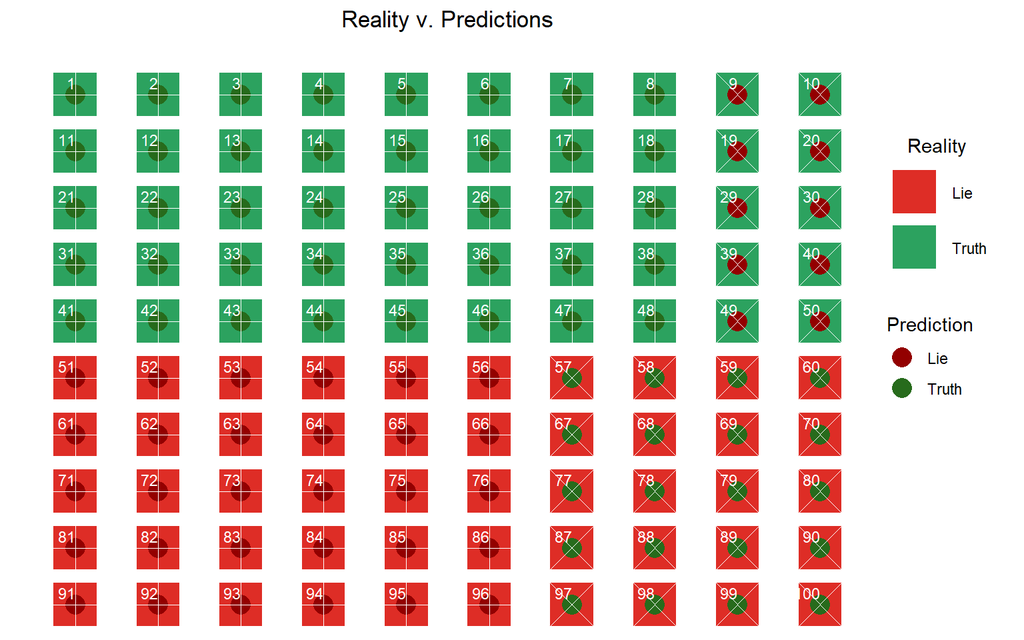

```r
# make plot
pred_plot <-
ggplot(data = example,
       aes(x = x_cord,
           y = y_cord)) +
  geom_point(aes(color = Reality),
             shape = 15, # full square
             size = 11) +
  scale_color_manual(values = c("#de2d26", "#2ca25f")) + # set custom color colors
  geom_point(aes(fill = Prediction),
             shape = 21, # outlined circle
             color = "transparent",
             size = 5) +
  scale_fill_manual(values = c("#930000", "#276b1c")) + # set custom fill colors
  geom_point(aes(shape = correct),
             size = 11,
             color = "white",
             position = position_nudge(x = 0, y = -0)) + # x = 0.1, y = -0.2
  scale_shape_manual(values = c(3, 4)) + # set custom shape shapes
  geom_text(aes(label = 1:100),
            size = 3,
            hjust = 1,
            vjust = -0.5,
            color = "white") +
  labs(title = "Reality v. Predictions",
       y = "",
       x = "") +
  scale_y_continuous(breaks = seq(from = 10, to = 0, by = -1),
                     trans = "reverse") +
  scale_x_continuous(breaks = seq(from = 0, to = 10, by = 1),
                     position = "top") +
  guides(color = guide_legend(order = 1),
         fill = guide_legend(order = 2),
         shape = guide_legend(order = 3,
                              title = NULL,
                              label = FALSE)) +
  theme(plot.title = element_text(hjust = 0.5),
        panel.grid.major = element_blank(),
        panel.grid.minor = element_blank(),
        panel.border = element_blank(),
        panel.background = element_blank(),
        axis.text.x=element_blank(),
        axis.ticks.x=element_blank(),
        axis.text.y=element_blank(),
        axis.ticks.y=element_blank(),
        legend.key = element_rect(color = "transparent", fill = "transparent"),
        legend.position = "right",
        legend.title.align = 0.5,
        legend.box.margin=margin(t = 0, b = 0, r = 10, l = 0))

# print plot (with overall accuracy highlighted)
pred_plot
```

## Overall Accuracy

Let’s start with the most basic metric of performance – overall accuracy. In our diagram, overall accuracy is the sum of all our correct predictions (the boxes with a plus sign) divided by our total number of predictions (the boxes with a plus sign plus the boxes with an X). Here that gives us 70% overall accuracy.

Mathematically, overall accuracy can also be thought of as:

$$\frac{\sum_{}^{}TRUEpositive + \sum_{}^{}TRUEnegative}{\sum_{}^{}TRUEpositive + \sum_{}^{}TRUEnegative + \sum_{}^{}FALSEpositive + \sum_{}^{}FALSEnegative}$$
For our example data, this calculation is also depicted in the figure below. The total number of boxes within the border of the solid black lines correspond the numerator in the equation above (70), and the total number of boxes within the border of the dotted black lines represent the denominator (100).

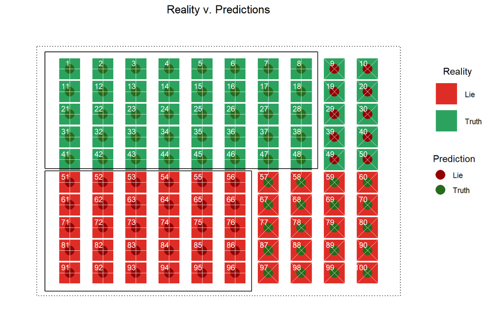

```r
# print plot (with overall accuracy highlighted)
pred_plot +
  geom_rect(aes(xmin = 0,
                xmax = 11,
                ymin = 0,
                ymax = 11),
            fill = "transparent",
            color = "black",
            linetype = "dotted") +
  geom_rect(aes(xmin = 0.25,
                xmax = 8.5,
                ymin = 0.25,
                ymax = 5.4),
            fill = "transparent",
            color = "black",
            linetype = "solid") +
  geom_rect(aes(xmin = 0.25,
                xmax = 6.5,
                ymin = 5.5,
                ymax = 10.8),
            fill = "transparent",
            color = "black",
            linetype = "solid")
```

## Sensitivity (“Truth Detection Rate”)

Another useful meric by which classification models are assessed is sensitivity (also called “recall”). Sensitivity is the percent of all “positive” outcomes that we actually detect. Here is an example. When we put our luggage through the x-ray machine at the airport, we can imagine that the machine is trying to detect whether our luggage has a gun in it or not (presence of a gun is a “positive” case). Sensitivity is the percent of all guns in suitcases that the x-ray machine actually finds. Such a machine could have very good overall accuracy simply by guessing that no one has a gun in their suitcase – because the vast majority of people don’t have guns in their suitcases. However, such a model would have poor sensitivity (in fact 0% sensitivity) because it would detect 0% of the suitcases that do have guns in them.

In our case, what sensitivity means depends on how we define our “positive” cases. If our task is “truth detection” (i.e. truth are “positive” cases), then sensitivity is the percent of all true statements that we correcntly predict to be true. In the figure, this is the sum of the green boxes with a green circle in them, divided by all the green boxes (both those with a green circle in them and those with a red circle in them). Here, that gives us 80%. (If our task were “lie detection” (i.e. lies were considered positive cases), then sensitivity would be the percent of all lies that we correctly identify as lies (red boxes with a red dot in them, divided by all red boxes). Unless stated otherwise, in this report, truths will always be considered “positive cases”. And thus sensitivity will correspond to a task of “truth detection” (i.e. truths are positive cases).)

Thus, in this particular case, we can think of sensitivity as the “truth detection rate” – the percent of all true statements that we correctly identify as true.

Mathematically, sensitivity is:

$$\frac{\sum_{}^{}TRUEpositive}{\sum_{}^{}TRUEpositive + \sum_{}^{}FALSEnegative}$$

Again, for our example data, this calculation is also depicted in the figure. The total number of boxes within the border of the solid black lines correspond the numerator in the equation above (40), and the total number of boxes within the border of the dotted black lines represent the denominator (50).

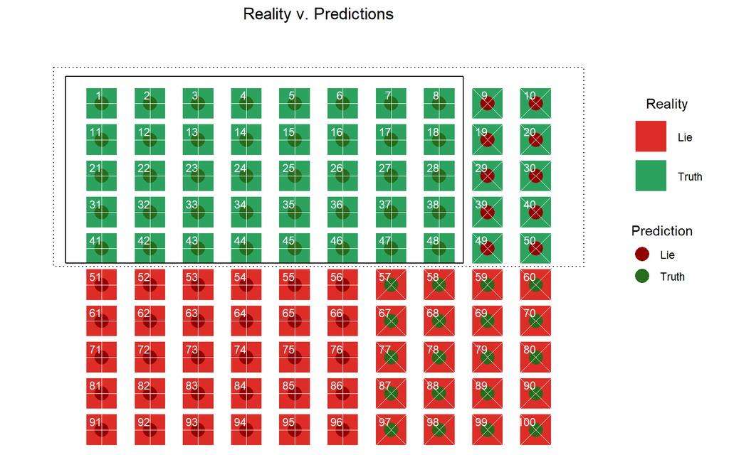

```r
pred_plot +
  geom_rect(aes(xmin = 0,
                xmax = 11,
                ymin = 0,
                ymax = 5.5),
            fill = "transparent",
            color = "black",
            linetype = "dotted") +
  geom_rect(aes(xmin = 0.25,
                xmax = 8.5,
                ymin = 0.25,
                ymax = 5.4),
            fill = "transparent",
            color = "black",
            linetype = "solid")
```

## Specificity (“Lie Detection Rate”)

Specificity is the other side of the coin, in a sense, of sensitivity. Specificity is the percent of all “negative” cases that a model correctly identifies. To continue with the X-ray machine example from above (where the task is “gun detection” in suitcases), specificity is the percent of all suitcases that do not have a gun, which we correctly identified as not having a gun. Again, if we turn off the X-ray machine and simply predict that no one has a gun, this “model” would have great (in fact, perfect, 100%) specificity. (Of course, to the detriment of sensitivity. Without perfect information, there is a tradeoff between sensitivity and specificity. We are always between the extremes of being overbroad and identifying everything as a positive case, thus achieving high sensitivity at the cost of low specificity, or being overly conservative erring on the side of not identifying anything as a positive case, thus achieving high specificity at the expensive of low sensitivity. This tradeoff can be depicted with the use of ROC curves, although I will not go into that here.)

In our case, if our task is “truth detection” (identifying true statements), then specificity is the proportion of all lies that we correctly identify as lies. Thus, here we can think of specificity as the “lie detection rate” of our model. For our example data of 100 statements that we can have been working with this would be the 60% (the red boxes with a red dot, divided by all the red boxes).

Mathematically, specificity is:
$$\frac{\sum_{}^{}TRUEnegative}{\sum_{}^{}TRUEnegative + \sum_{}^{}FALSEpositive}$$

Again, for our example data, this calculation is also depicted in the figure. The total number of boxes within the border of the solid black lines correspond the numerator in the equation above (30), and the total number of boxes within the border of the dotted black lines represent the denominator (50).

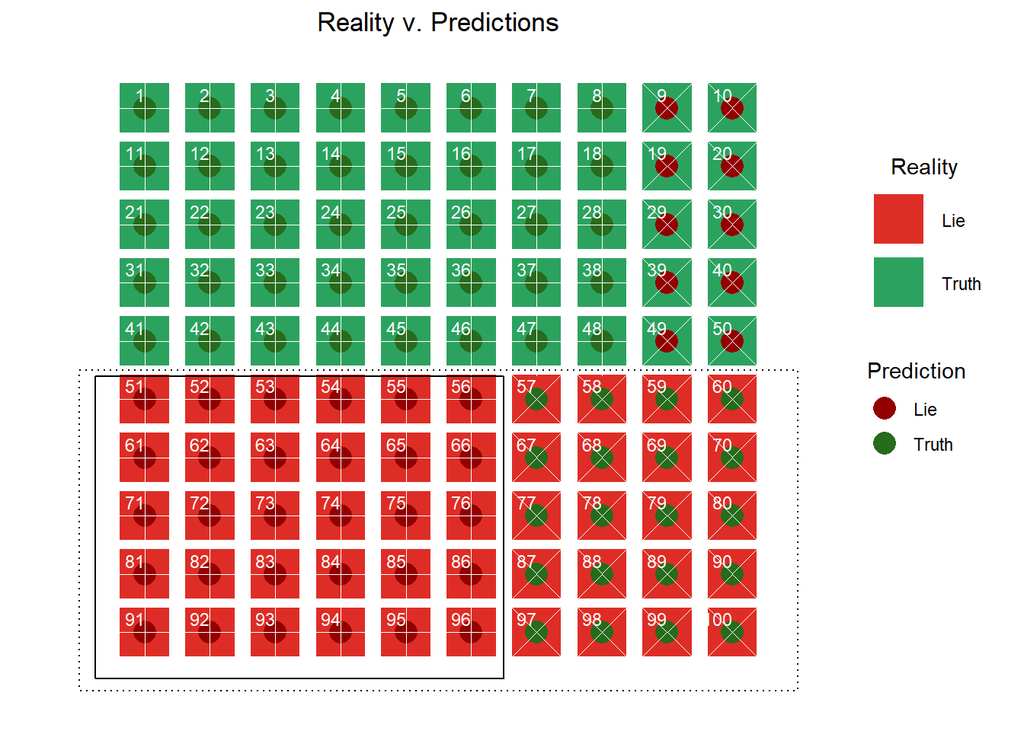

```r
pred_plot +
  geom_rect(aes(xmin = 0,
                xmax = 11,
                ymin = 5.5,
                ymax = 11),
            fill = "transparent",
            color = "black",
            linetype = "dotted") +
  geom_rect(aes(xmin = 0.25,
                xmax = 6.5,
                ymin = 5.6,
                ymax = 10.8),
            fill = "transparent",
            color = "black",
            linetype = "solid")
```

## Precision (“Non-Gullibility”)

In a sense, the previous metrics focused on outcomes. That is, we looked at metrics that assessed how well our model could identity positive cases (sensitivity, e.g. “truths”) or how well our model could identify negative cases (specificity, e.g. “lies”). These next two metrics are more focused on predictions. The first such metric I will explain is “precision” (also called positive predictive value). Most simply, this can be thought of as the percent of times that a model is correct when it predicts a “positive” outcome. To continue with the x-ray machine example, it is the percentage of times that, after the machine beeps (predicts a suitcase has a gun), that suitcase actually has a gun.

In our case, assuming our task is “truth detection”, it is the percent of the time that a statement is true given that we’ve predicted the statement is true. It can be thought as measuring a model’s “non-gullibility”. If someone is not gullible, then they have high precision (a large proportion of the statements they predict to be true are in fact true). In the figure below for our example data, precision, is the sum of all green boxes with a green circle in them divided by all boxes which have a green circle in them (66.7%).

Mathematically, precision is:

$$\frac{\sum_{}^{}TRUEpositive}{\sum_{}^{}TRUEpositive + \sum_{}^{}FALSEpositive}$$

Again, for our example data, this calculation is also depicted in the figure. The total number of boxes within the border of the solid black lines correspond the numerator in the equation above (40), and the total number of boxes within the border of the dotted black lines represent the denominator (60).

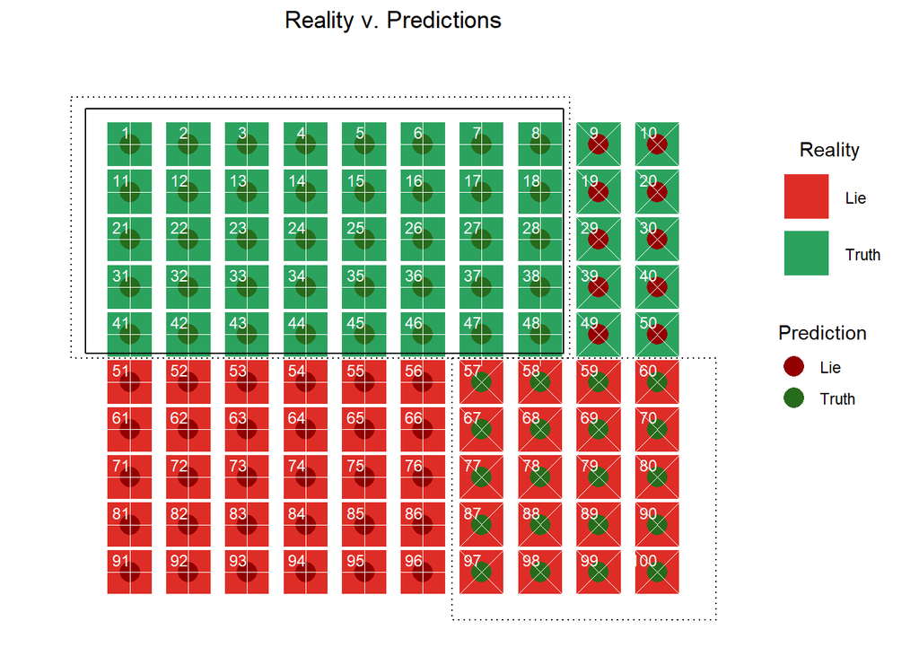

```r
pred_plot +
  geom_rect(aes(xmin = 0,
                xmax = 8.5,
                ymin = 0,
                ymax = 5.5),
            fill = "transparent",
            color = "black",
            linetype = "dotted") +
  geom_rect(aes(xmin = 6.5,
                xmax = 11,
                ymin = 5.5,
                ymax = 11),
            fill = "transparent",
            color = "black",
            linetype = "dotted") +
  geom_rect(aes(xmin = 0.25,
                xmax = 8.4,
                ymin = 0.25,
                ymax = 5.4),
            fill = "transparent",
            color = "black",
            linetype = "solid")
```

## Negative Predictive Value (“Well-Founded Skepticism”)

Again, there is another side of the coin to the precision metric, as there was for the sensitivity metric. Negative predictive value is, in a sense, the other side of the coin of precision. It measures of the percent of cases that are labeled as “negative” which are true negatives. In the x-ray example, it is the proportion of times when a suitcase does not set off the machine’s alarm that the suitcase actually does not have a gun in it.

In our case, assuming again our task is “truth detection”, negative predictive value is the proportion of statements that we predict to be lies which are actually lies. Negative predictive value can be thought of as “well-founded skepticism”. If someone is high in well-founded skepticism (negative predictive value), a large portion of the statements they believe to be lies turn out in fact to be lies. In the figure below, negative predictive value is the total number of red boxes that also have a red circle in them divided by the total number of boxes with a red circle in them (75%).

Mathematically, negative predictive value is:

$$\frac{\sum_{}^{}TRUEnegative}{\sum_{}^{}TRUEnegative + \sum_{}^{}FALSEnegative}$$

Again, for our example data, this calculation is also depicted in the figure. The total number of boxes within the border of the solid black lines correspond the numerator in the equation above (30), and the total number of boxes within the border of the dotted black lines represent the denominator (40).

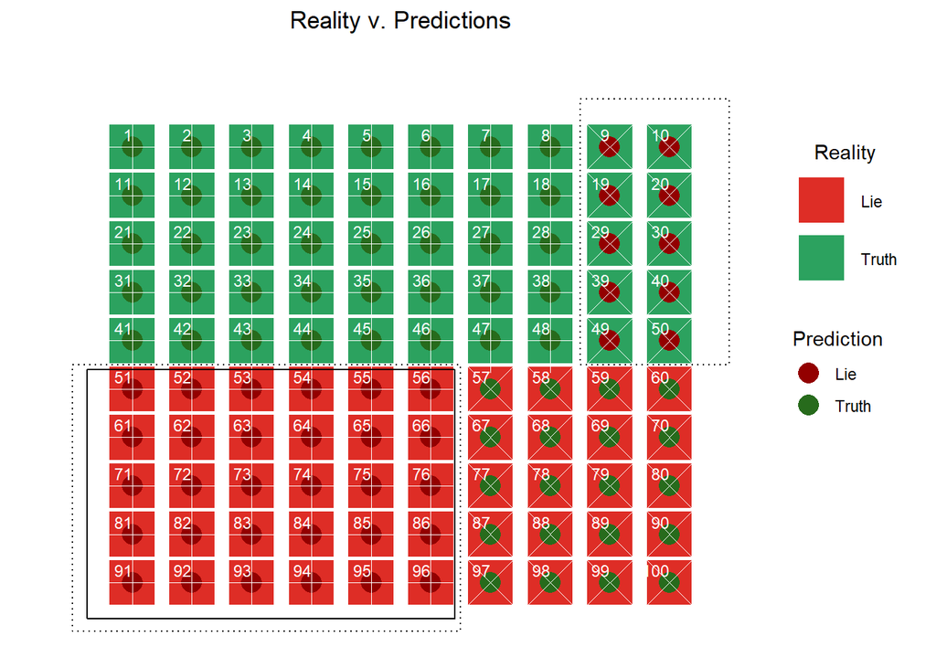

```r
pred_plot +
  geom_rect(aes(xmin = 8.5,
                xmax = 11,
                ymin = 0,
                ymax = 5.5),
            fill = "transparent",
            color = "black",
            linetype = "dotted") +
  geom_rect(aes(xmin = 0,
                xmax = 6.5,
                ymin = 5.5,
                ymax = 11),
            fill = "transparent",
            color = "black",
            linetype = "dotted") +
  geom_rect(aes(xmin = 0.25,
                xmax = 6.4,
                ymin = 5.6,
                ymax = 10.75),
            fill = "transparent",
            color = "black",
            linetype = "solid")
```

## Other performance metrics

There are a host of other important metrics and tools to assess classification performance, which I will not discuss for the time being – but are nevertheless useful and provide insight into a model’s performance. Lest I fail to mention them entirely, these include:

- Kappa
- F1 scores
- ROC curves
- AUC (area under the curve)
- Calibration Plots

# Data Splitting, for Model Training and Testing

The golden rule in predictive modeling is to never use the same data that the model was built on to assess the model’s performance. All of the above has presupposed that we have already trained (“fit”) a model on a certain portion of a dataset and are now using that model to make predictions on a different portion of the dataset. However, there are actually many different strategies for how to split the data into training and test sets. The most popular of these tend to fall into one of these three categories (Kuhn & Johnson, 2013, Chapter 4):

- k-fold cross validation
- repeated training/testing splits
- bootstrapping

Each of these provide a different process for repeated splitting up a dataset into training and testing portions, and evaluating the performance of a model over and over.

## K-fold cross validation

For example, we can imagine a dataset with 100 rows. In 10-fold cross validation, we would divide this dataset into 10 different junks: chunk 1 (consisting of 10 rows), chunk 2 (consisting of a different 10 rows), chunk 3 (consisting of yet another set of 10 rows), and so on up until chunk 10, whereupon each of our 100 observations will be in one of the 10 chunks. (Usually, allocation to chunks is done through randomization.) Then, in the first round of model building, we could fit a model to chunks 1-9 combined, and test the performance of that model by making predictions on chunk 10. In the next round, we could fit a model to chunks 1-8 & 10 combined, and test the performance of that model by making predictions on chunk 9. In round after that, we could fit a model to chunks 1-7 & 9-10 combined, and then test the performance of that model by making predictions on chunk 8. And so on, until we have done this 10 times (each of the 10 chunks will have been used as a testing set once). (A very common type of k-fold cross validation is indeed 10-fold cross validation.)

A key feature of k-fold cross validation is that across our k rounds of training and training, none of the rows that are used in one round of testing will ever be used again in another round of testing. This is depicted below in a figure from (Kuhn & Johnson, 2013, p.71). They depict a hypothetical dataset consisting of 12 observations (“rows” in my terminology). We then see how model training and testing proceeds in a case of 3-fold cross validation on this dataset. In the first round, the first chunk of the data is used as the testing set and the remaining two chunks are used for training. In the next round, the second (middle) chunk of the data is used as the testing set and the remaining two chunks are used for training. And in the third and final round, the third (last) chunk of the data is used as the testing set and the other two chunks are used for training. In each of these rounds (assuming we are doing binary classification), we could extract the metrics 5 metrics reviewed above (overall accuracy, sensitivity, specificity, precision, and negative predictive value). We could also look at average peformance on these 5 metrics across the k rounds.

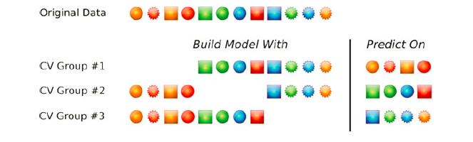

## Repeated training/testing splits

Another way of conducting k round of training and testing is by employing a training-testing strategy alternatively referred to as repeated training/testing splits, “leave-group-out crossvalidation”, or or “Monte Carlo cross-validation” (Kuhn & Johnson, 2013, p.71). This is very similar k-fold cross validation, except we randomly generate our training and testing sets for each of our k training and testing rounds. In each round, we pick a portion of our data’that we want to be in training set and a portion of our data that we want to be in our testing set (e.g. 90% training, 10% testing). In each round, we then randomly sample rows without replacement to determine which rows will be in our training set and which will be in our testing set. As with k-fold cross validation, these means that, in any given round, a row will never appear in both our training and testing set. However, unlike k-fold cross validation, this does allow that across different training and testing rounds, a row that appeared in a testing set in one round may appear again in the testing set used in another round. Again, this is depicted schematically by Kuhn & Johnson (2013, p.72) in the figure below. Using the same hypothetical dataset of 12 rows, they show how 3 rounds of repeated training/testing split would proceed. In each round, the portion of the dataset used for training is 66.6% (i.e. 8/12), with the remaining data used in the testing set. However, these are now determined by random sampling without replacement–and thus datapoints can reappear in testing sets (e.g. we see spiky green circle in the testing set in both rounds 2 and 3).

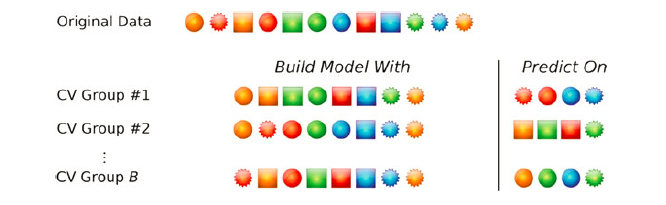

## Bootstrapping

The final major data splitting strategy is bootstrapping. It is almost exactly like the “Monte Carlo cross-validation” reviewed just above, except that in each training-testing round, rows are sampled *with* replacement. Bootstrapping is often used in cases where the dataset does not contain that many observations. In these cases, methods like k-fold cross validation or “Monte Carlo cross-validation”, limit the amount of data that can be used for training because the dataset is always split up, with only some portion of the full dataset going into the training set. With bootstrapping, in each round of training and testing, some portion of the observations are selected to create the training set and the other portion is used to create the testing set. However, observations are sampled with replacement both to create the training set and the testing set. Thus, the same observation might appear multiple times in the training set or multiple times in the training set. This allows us to build larger training sets that we might otherwise be able to. And indeed with bootstrapping, the rows selected for the training set are resampled with replacement until the training set is the same size as the original dataset (Kuhn & Johnson, 2013, p.72).

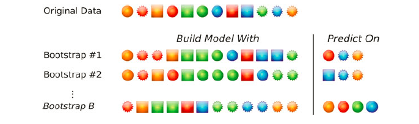

## Procedure For Our Models

When I evaluate various models that I will create in later sections, I will keep the method of data splitting constant. Specifically, I will always used a repeated training/testing splits (“Monte Carlo cross-validation”). To assess overall performance, I will conduct 10 rounds of testing and training. In each round, the dataset will be split exactly in half (i.e. 50-50 split). Using random sampling without replacement, one half of the dataset will be used for the training set and the other half will be used for the testing set. For final model evaluation, the average performance across these 10 models will be recorded. And this will consitute the official performance of that model type.

I prefer this technique for a few reasons. First, we have a fairly large amount of data (5,004 rows). So we have enough data to “spare” that we don’t *have to* use bootstrapping if we don’t want to. Even though bootstrapping is a perfectly legitimate technique for data splitting, I’d like to avoid using the same observation multiple times if we can in the training set if. That leaves a choice between k-fold cross validation and repeated testing/training splits (“Monte Carlo cross-validation”). I choose the latter strategy because I’d like to allocate exactly equal amounts of data to the training set and the testing set. With k-fold cross validation this is only possible if we conduct 2-fold cross validation (with 2 chunks, and 2 rounds of training and testing). With “Monte Carlo cross-validation”, we can conduct arbitrarily many rounds of training-testing, with a 50-50 split each time – because in each round, we are sampling from the full dataset anew (rather than re-arranging the same sets of chunks across rounds).

# Citations

These are some very useful resources to understanding some of the ways that classification performance can be assessed.

- Sensitivity and specificity. (2018). In Wikipedia. Retrieved from https://en.wikipedia.org/w/index.php?title=Sensitivity_and_specificity&oldid=868941362
- Confusion matrix. (2018). In Wikipedia. Retrieved from https://en.wikipedia.org/w/index.php?title=Confusion_matrix&oldid=865598510
- Kuhn, M., & Johnson, K. (2013). Applied predictive modeling (Vol. 26). Springer. (see Chapter 11: Measuring Performance in Classification Models & Chapter 4: Overfitting and Model Tuning)